# Chapter 9

Julin Maloof

2023-01-16

# Chapter 9

```r
library(tidyverse)
```

## 9.2.6 Exercises

### 1.

Use `as_mapper()` to explore how purrr generates anonymous functions for the integer, character, and list helpers. What helper allows you to extract attributes? Read the documentation to find out.

```r
f <- as_mapper(~ . + 1)
f
```

```
## <lambda>
## function (..., .x = ..1, .y = ..2, . = ..1)
## . + 1
## attr(,"class")
## [1] "rlang_lambda_function" "function"
```

```r
f(1:3)
```

```
## [1] 2 3 4
```

```r
f <- as_mapper(2)
f
```

```
## function (x, ...)
## pluck_raw(x, list(2), .default = NULL)
## <environment: 0x11a3a4270>
```

```r
f(3:1)
```

```
## [1] 2
```

```r
f <- as_mapper(c("a", "b", "c"))
f
```

```
## function (x, ...)
## pluck_raw(x, list("a", "b", "c"), .default = NULL)
## <environment: 0x11948b0d0>
```

```r
f(1:3)
```

[output not shown]

```r
f(c(a=4,b=3, c=1))
```

[output not shown]

```r
f(list(a=4,b=3,c=1))
```

[output not shown]

```r
f(list(a=list(b=list(c=23))))
```

```
## [1] 23
```

Ahhh, each argument takes you one level deeper into the list

Can use attr_getter

```r
f <- attr_getter("class")
f
```

```
## function (x)
## attr(x, attr, exact = TRUE)
## <bytecode: 0x10fbd46e8>
## <environment: 0x10fbd4a30>
```

```r
f(mpg)
```

```
## [1] "tbl_df"     "tbl"        "data.frame"
```

### 2.

map(1:3, ~ runif(2)) is a useful pattern for generating random numbers, but map(1:3, runif(2)) is not. Why not? Can you explain why it returns the result that it does?

```r
map(1:3, ~ runif(2))
```

```
## [[1]]
## [1] 0.9948546 0.8536885
##
## [[2]]
## [1] 0.9317614 0.3424511
##
## [[3]]
## [1] 0.8489826 0.1375176
```

```r
map(1:3, runif(2))
```

```
## [[1]]
## [1] 1
##
## [[2]]
## [1] 2
##
## [[3]]
## [1] 3
```

```r
as_mapper(runif(2))
```

```
## function (x, ...)
## pluck_raw(x, list(0.201595538528636, 0.444256887771189), .default = NULL)
## <environment: 0x11be81328>
```

_In the second form, the output from `runif(2)` is taken as input to `as_mapper` and interpreted as positions? names? to extract

### 3.

Use the appropriate map() function to:

1. Compute the standard deviation of every column in a numeric data frame.

```r
df <- as_data_frame(matrix(rnorm(100),ncol=5))
df
```

```
## # A tibble: 20 × 5
##         V1      V2      V3     V4      V5
##      <dbl>   <dbl>   <dbl>  <dbl>   <dbl>
##  1  0.232   0.227   0.152  -0.738 -2.06
##  2 -0.552   0.702  -0.0614  1.06  -1.17
##  3 -1.13   -0.554   0.329   2.50  -0.930
##  4  0.620  -0.944   0.166  -0.327 -0.666
##  5 -0.823  -0.539  -0.586   1.15  -1.21
##  6 -1.84   -0.510   0.903  -0.192  0.192
##  7 -0.355  -0.381  -0.467  -0.617  0.167
##  8  0.925   0.567   0.698   0.450  0.415
##  9 -0.276  -0.212  -0.523   1.03  -1.24
## 10 -0.425   1.53    0.964  -0.698 -1.67
## 11  0.736   0.726  -1.27    0.465  0.123
## 12  1.06    1.24   -0.551   1.07  -2.96
## 13  1.38    0.358   0.259  -0.615 -0.0179
## 14 -0.0658  0.717   0.335   0.522  0.156
## 15  1.24    1.76    0.762  -1.91  -0.167
## 16 -0.980  -0.0660 -0.770  -0.794  0.252
## 17 -1.07    0.179  -0.174  -0.545 -1.38
## 18 -1.23    0.522  -0.817   0.238  0.0367
## 19  1.46    0.855  -1.66   -0.484  0.886
## 20 -0.0852 -0.695   1.35    1.77   0.413
```

```r
map_dbl(df, sd)
```

```
##        V1        V2        V3        V4        V5
## 0.9769210 0.7599802 0.7854698 1.0514679 0.9959031
```

2. Compute the standard deviation of every numeric column in a mixed data frame. (Hint: you’ll need to do it in two steps.)

```r
columns <- map_lgl(mpg, is.numeric)
map_dbl(mpg[columns], sd)
```

```
##    displ     year      cyl      cty      hwy
## 1.291959 4.509646 1.611534 4.255946 5.954643
```

Or

```r
mpg %>%
  summarize(across(.cols = where(is.numeric), sd ))
```

```
## # A tibble: 1 × 5
##   displ  year   cyl   cty   hwy
##   <dbl> <dbl> <dbl> <dbl> <dbl>
## 1  1.29  4.51  1.61  4.26  5.95
```

3. Compute the number of levels for every factor in a data frame.

```r
columns <- map_lgl(iris, is.factor)
map_dbl(iris[columns], nlevels)
```

```
## Species
##       3
```

### 4.

The following code simulates the performance of a t-test for non-normal data. Extract the p-value from each test, then visualise.

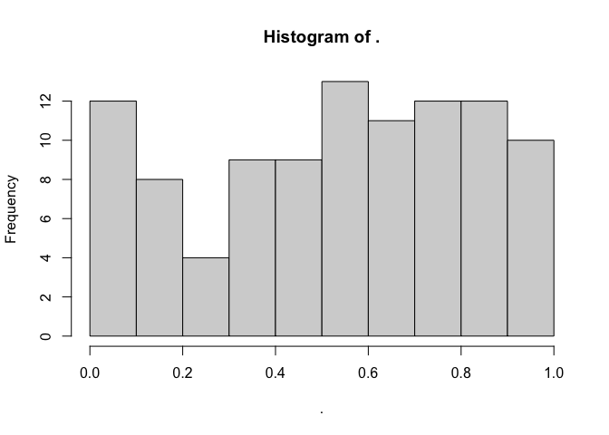

```r
trials <- map(1:100, ~ t.test(rpois(10, 10), rpois(7, 10)))

map_dbl(trials, "p.value") %>%
  hist()
```

### 5.

The following code uses a map nested inside another map to apply a function to every element of a nested list. Why does it fail, and what do you need to do to make it work?

```r
x <- list(
  list(1, c(3, 9)),
  list(c(3, 6), 7, c(4, 7, 6))
)

triple <- function(x) x * 3

map(x, ~ map(.x, .f= triple))
```

```
## [[1]]
## [[1]][[1]]
## [1] 3
##
## [[1]][[2]]
## [1]  9 27
##
##
## [[2]]
## [[2]][[1]]
## [1]  9 18
##
## [[2]][[2]]
## [1] 21
##
## [[2]][[3]]
## [1] 12 21 18
```

```r
#map(x, map, .f = triple)
```

```
#> Error in .f(.x[[i]], ...): unused argument (function (.x, .f, ...)
#> {
#> .f <- as_mapper(.f, ...)
#> .Call(map_impl, environment(), ".x", ".f", "list")
#> })
```

*The problem was that the “.f” argument was going to the outer map.*

### 6.

Use map() to fit linear models to the mtcars dataset using the formulas stored in this list:

```r
formulas <- list(
  mpg ~ disp,
  mpg ~ I(1 / disp),
  mpg ~ disp + wt,
  mpg ~ I(1 / disp) + wt
)

map(formulas, lm, data=mtcars)
```

```
## [[1]]
##
## Call:
## .f(formula = .x[[i]], data = ..1)
##
## Coefficients:
## (Intercept)         disp
##    29.59985     -0.04122
##
##
## [[2]]
##
## Call:
## .f(formula = .x[[i]], data = ..1)
##
## Coefficients:
## (Intercept)    I(1/disp)
##       10.75      1557.67
##
##
## [[3]]
##
## Call:
## .f(formula = .x[[i]], data = ..1)
##
## Coefficients:
## (Intercept)         disp           wt
##    34.96055     -0.01772     -3.35083
##
##
## [[4]]
##
## Call:
## .f(formula = .x[[i]], data = ..1)
##
## Coefficients:
## (Intercept)    I(1/disp)           wt
##      19.024     1142.560       -1.798
```

Better…

```r
tib <- tibble(formulas = list(
  mpg ~ disp,
  mpg ~ I(1 / disp),
  mpg ~ disp + wt,
  mpg ~ I(1 / disp) + wt
))

tib <- tib %>%
  mutate(lm = map(formulas, lm, mtcars))

tib %>% mutate(glance = map(lm, broom::glance)) %>% unnest(glance)
```

```
## # A tibble: 4 × 14
##   formulas  lm     r.squared adj.r.s…¹ sigma stati…²  p.value    df logLik   AIC
##   <list>    <list>     <dbl>     <dbl> <dbl>   <dbl>    <dbl> <dbl>  <dbl> <dbl>
## 1 <formula> <lm>       0.718     0.709  3.25    76.5 9.38e-10     1  -82.1  170.
## 2 <formula> <lm>       0.860     0.855  2.29   184.  2.49e-14     1  -71.0  148.
## 3 <formula> <lm>       0.781     0.766  2.92    51.7 2.74e-10     2  -78.1  164.
## 4 <formula> <lm>       0.884     0.876  2.12   110.  2.79e-14     2  -67.9  144.
## # … with 4 more variables: BIC <dbl>, deviance <dbl>, df.residual <int>,
## #   nobs <int>, and abbreviated variable names ¹adj.r.squared, ²statistic
```

```r
tib %>% mutate(tidy = map(lm, broom::tidy)) %>% unnest(tidy)
```

```
## # A tibble: 10 × 7
##    formulas  lm     term         estimate std.error statistic  p.value
##    <list>    <list> <chr>           <dbl>     <dbl>     <dbl>    <dbl>
##  1 <formula> <lm>   (Intercept)   29.6      1.23        24.1  3.58e-21
##  2 <formula> <lm>   disp          -0.0412   0.00471     -8.75 9.38e-10
##  3 <formula> <lm>   (Intercept)   10.8      0.799       13.5  3.06e-14
##  4 <formula> <lm>   I(1/disp)   1558.     115.          13.6  2.49e-14
##  5 <formula> <lm>   (Intercept)   35.0      2.16        16.2  4.91e-16
##  6 <formula> <lm>   disp          -0.0177   0.00919     -1.93 6.36e- 2
##  7 <formula> <lm>   wt            -3.35     1.16        -2.88 7.43e- 3
##  8 <formula> <lm>   (Intercept)   19.0      3.45         5.51 6.13e- 6
##  9 <formula> <lm>   I(1/disp)   1143.     200.           5.72 3.47e- 6
## 10 <formula> <lm>   wt            -1.80     0.733       -2.45 2.04e- 2
```

### 7.

Fit the model mpg ~ disp to each of the bootstrap replicates of mtcars in the list below, then extract the $R^2$ of the model fit (Hint: you can compute the $R^2$ with summary().)

```r
bootstrap <- function(df) {
  df[sample(nrow(df), replace = TRUE), , drop = FALSE]
}

bootstraps <- map(1:10, ~ bootstrap(mtcars))

map(bootstraps, ~ lm(mpg ~ disp, .x)) %>%
  map(summary) %>%
  map_dbl("r.squared")
```

```
##  [1] 0.5899277 0.7261259 0.6631362 0.7634222 0.6202728 0.6363056 0.7375201
##  [8] 0.7609964 0.7045286 0.6977526
```

## 9.4.6 Exercises

### 1.

Explain the results of modify(mtcars, 1).

```r
mtcars
```

```
##                      mpg cyl  disp  hp drat    wt  qsec vs am gear carb
## Mazda RX4           21.0   6 160.0 110 3.90 2.620 16.46  0  1    4    4
## Mazda RX4 Wag       21.0   6 160.0 110 3.90 2.875 17.02  0  1    4    4
## Datsun 710          22.8   4 108.0  93 3.85 2.320 18.61  1  1    4    1
## Hornet 4 Drive      21.4   6 258.0 110 3.08 3.215 19.44  1  0    3    1
## Hornet Sportabout   18.7   8 360.0 175 3.15 3.440 17.02  0  0    3    2
## Valiant             18.1   6 225.0 105 2.76 3.460 20.22  1  0    3    1
## Duster 360          14.3   8 360.0 245 3.21 3.570 15.84  0  0    3    4
## Merc 240D           24.4   4 146.7  62 3.69 3.190 20.00  1  0    4    2
## Merc 230            22.8   4 140.8  95 3.92 3.150 22.90  1  0    4    2
## Merc 280            19.2   6 167.6 123 3.92 3.440 18.30  1  0    4    4
## Merc 280C           17.8   6 167.6 123 3.92 3.440 18.90  1  0    4    4
## Merc 450SE          16.4   8 275.8 180 3.07 4.070 17.40  0  0    3    3
## Merc 450SL          17.3   8 275.8 180 3.07 3.730 17.60  0  0    3    3
## Merc 450SLC         15.2   8 275.8 180 3.07 3.780 18.00  0  0    3    3
## Cadillac Fleetwood  10.4   8 472.0 205 2.93 5.250 17.98  0  0    3    4
## Lincoln Continental 10.4   8 460.0 215 3.00 5.424 17.82  0  0    3    4
## Chrysler Imperial   14.7   8 440.0 230 3.23 5.345 17.42  0  0    3    4
## Fiat 128            32.4   4  78.7  66 4.08 2.200 19.47  1  1    4    1
## Honda Civic         30.4   4  75.7  52 4.93 1.615 18.52  1  1    4    2
## Toyota Corolla      33.9   4  71.1  65 4.22 1.835 19.90  1  1    4    1
## Toyota Corona       21.5   4 120.1  97 3.70 2.465 20.01  1  0    3    1
## Dodge Challenger    15.5   8 318.0 150 2.76 3.520 16.87  0  0    3    2
## AMC Javelin         15.2   8 304.0 150 3.15 3.435 17.30  0  0    3    2
## Camaro Z28          13.3   8 350.0 245 3.73 3.840 15.41  0  0    3    4
## Pontiac Firebird    19.2   8 400.0 175 3.08 3.845 17.05  0  0    3    2
## Fiat X1-9           27.3   4  79.0  66 4.08 1.935 18.90  1  1    4    1
## Porsche 914-2       26.0   4 120.3  91 4.43 2.140 16.70  0  1    5    2
## Lotus Europa        30.4   4  95.1 113 3.77 1.513 16.90  1  1    5    2
## Ford Pantera L      15.8   8 351.0 264 4.22 3.170 14.50  0  1    5    4
## Ferrari Dino        19.7   6 145.0 175 3.62 2.770 15.50  0  1    5    6
## Maserati Bora       15.0   8 301.0 335 3.54 3.570 14.60  0  1    5    8
## Volvo 142E          21.4   4 121.0 109 4.11 2.780 18.60  1  1    4    2
```

```r
modify(mtcars, 1)
```

```
##    mpg cyl disp  hp drat   wt  qsec vs am gear carb
## 1   21   6  160 110  3.9 2.62 16.46  0  1    4    4
## 2   21   6  160 110  3.9 2.62 16.46  0  1    4    4
## 3   21   6  160 110  3.9 2.62 16.46  0  1    4    4
## 4   21   6  160 110  3.9 2.62 16.46  0  1    4    4
## 5   21   6  160 110  3.9 2.62 16.46  0  1    4    4
## 6   21   6  160 110  3.9 2.62 16.46  0  1    4    4
## 7   21   6  160 110  3.9 2.62 16.46  0  1    4    4
## 8   21   6  160 110  3.9 2.62 16.46  0  1    4    4
## 9   21   6  160 110  3.9 2.62 16.46  0  1    4    4
## 10  21   6  160 110  3.9 2.62 16.46  0  1    4    4
## 11  21   6  160 110  3.9 2.62 16.46  0  1    4    4
## 12  21   6  160 110  3.9 2.62 16.46  0  1    4    4
## 13  21   6  160 110  3.9 2.62 16.46  0  1    4    4
## 14  21   6  160 110  3.9 2.62 16.46  0  1    4    4
```

[output cut: 18 more lines]

*Oh, I see it is going to go through each item in the last (each column) and then take the first item there*

### 2.

Rewrite the following code to use iwalk() instead of walk2(). What are the advantages and disadvantages?

```r
temp <- "./temp"
cyls <- split(mtcars, mtcars$cyl)
paths <- file.path(temp, paste0("cyl-", names(cyls), ".csv"))
walk2(cyls, paths, write.csv)
```

```r
cyls <- split(mtcars, mtcars$cyl)
iwalk(cyls, ~ write.csv(.x, file.path(temp, paste0("cyl-", .y, ".csv"))))
```

*fewer lines and variable, but maybe harder to read*

### 3. Explain how the following code transforms a data frame using functions stored in a list.

```r
trans <- list(
  disp = function(x) x * 0.0163871,
  am = function(x) factor(x, labels = c("auto", "manual"))
)

nm <- names(trans)
mtcars[nm] <- map2(trans, mtcars[nm], function(f, var) f(var))
```

*trans is a list of 2 functions; mtcars[nm] is a list of 2 columns. map applies the first function to the first column, etc*.

Compare and contrast the map2() approach to this map() approach:

```r
mtcars[nm] <- map(nm, ~ trans[[.x]](mtcars[[.x]]))
```

*ugly!*

### 4.

What does write.csv() return, i.e. what happens if you use it with map2() instead of walk2()?

```r
temp <- "./temp"
cyls <- split(mtcars, mtcars$cyl)
paths <- file.path(temp, paste0("cyl-", names(cyls), ".csv"))
map2(cyls, paths, write.csv)
```

[output not shown]

## 9.6.3 Exercises

### 1. Why isn’t is.na() a predicate function? What base R function is closest to being a predicate version of is.na()?

My understanding is that a predicate function is one that will return a single value regardless of the length of the input. `is.na()` is vectorized and so will return values the same length as the object.

`anyNA()` is a predicate version of this.

```r
x <- c(1,2,3,NA,4,NA,5)
is.na(x)
```

```
## [1] FALSE FALSE FALSE  TRUE FALSE  TRUE FALSE
```

```r
anyNA(x)
```

```
## [1] TRUE
```

### 2. simple_reduce() has a problem when x is length 0 or length 1. Describe the source of the problem and how you might go about fixing it.

```r
simple_reduce <- function(x, f) {
  out <- x[[1]]
  for (i in seq(2, length(x))) {
    out <- f(out, x[[i]])
  }
  out
}

simple_reduce(1:10, max)
```

```
## [1] 10
```

```r
simple_reduce(1, max)
```

```
## Error in x[[i]]: subscript out of bounds
```

The problem is the seq command that assumes x is at least length 2. Adding an init value will solve length =1 problems. And maybe just returning NULL if length = 0.

### 3. Implement the span() function from Haskell: given a list x and a predicate function f, span(x, f) returns the location of the longest sequential run of elements where the predicate is true. (Hint: you might find rle() helpful.)

```r
x <- list(1:5, 8:9, 5, c("a","b"), LETTERS, 10:12, letters)

span <- function(x, f){
  rlex <- map(x, f) %>%
    unlist() %>%
    rle()

  start <- NULL
  end <- NULL
  best <- 0
  for(i in 1:length(rlex$lengths)) {
    if (rlex$values[i] & (rlex$lengths[i] > best)) {
      #update
      best <- rlex$lengths[i]
      end <- sum(rlex$lengths[1:i])
      start <- end - rlex$lengths[i] + 1
    }
  }
  return(c(start, end))
}

span(x, is.character)
```

```
## [1] 4 5
```

### 4. Implement arg_max(). It should take a function and a vector of inputs, and return the elements of the input where the function returns the highest value. For example, arg_max(-10:5, function(x) x ^ 2) should return -10. arg_max(-5:5, function(x) x ^ 2) should return c(-5, 5). Also implement the matching arg_min() function.

```r
arg_max <- function(x, f) {
  x[which.max(map(x, f))]
}

arg_max(-10:5, function(x) x ^ 2)
```

```
## [1] -10
```

```r
arg_max(5:-10, function(x) x ^ 2)
```

```
## [1] -10
```

### 5. The function below scales a vector so it falls in the range [0, 1]. How would you apply it to every column of a data frame? How would you apply it to every numeric column in a data frame?

```r
scale01 <- function(x) {
  rng <- range(x, na.rm = TRUE)
  (x - rng[1]) / (rng[2] - rng[1])
}
```

```r
modify_if(diamonds, is.numeric, scale01)
```

```
## # A tibble: 53,940 × 10
##      carat cut       color clarity depth table     price     x      y      z
##      <dbl> <ord>     <ord> <ord>   <dbl> <dbl>     <dbl> <dbl>  <dbl>  <dbl>
##  1 0.00624 Ideal     E     SI2     0.514 0.231 0         0.368 0.0676 0.0764
##  2 0.00208 Premium   E     SI1     0.467 0.346 0         0.362 0.0652 0.0726
##  3 0.00624 Good      E     VS1     0.386 0.423 0.0000541 0.377 0.0691 0.0726
##  4 0.0187  Premium   I     VS2     0.539 0.288 0.000433  0.391 0.0718 0.0827
##  5 0.0229  Good      J     SI2     0.564 0.288 0.000487  0.404 0.0739 0.0865
##  6 0.00832 Very Good J     VVS2    0.55  0.269 0.000541  0.367 0.0672 0.0780
##  7 0.00832 Very Good I     VVS1    0.536 0.269 0.000541  0.368 0.0676 0.0777
##  8 0.0125  Very Good H     SI1     0.525 0.231 0.000595  0.379 0.0698 0.0796
##  9 0.00416 Fair      E     VS2     0.614 0.346 0.000595  0.360 0.0642 0.0783
## 10 0.00624 Very Good H     VS1     0.456 0.346 0.000649  0.372 0.0688 0.0752
## # … with 53,930 more rows
```

## 9.7.3 Exercises

### 1. How does apply() arrange the output? Read the documentation and perform some experiments.

### 2. What do eapply() and rapply() do? Does purrr have equivalents?

### 3. Challenge: read about the fixed point algorithm. Complete the exercises using R.

```r
fp <- function(x, FUN) {
  abs(x-FUN(x))
}

optimize(fp, c(-10,10), function(x) x^2)
```

```
## $minimum
## [1] 1.000014
##
## $objective
## [1] 1.407851e-05
```